# Gogoeta metalinguistikoa

Hizkuntzaren Didaktika

# Hizkuntzaren inguruko jarduera metalinguistikoa

### Zer da?

- Portaera linguistikoa
- Kontrol ez kontzientea
- Ezagutza inplizitua: Hitz bat beste baten ordez aukeratzea, errepikatzea argiago azaltzeko, esandako zerbait zuzentzea okerraz jabetuta…

(Rodríguez, 2013) Actividad metalingüística y reflexión gramatical

> La facultad metalingüística es la posibilidad que tenemos los humanos de elevarnos por encima de la lengua y de contemplarla, al tiempo que la utilizamos en la comunicación.

> – BENVENISTE (1966)

# Gramatika esplizitua

Letrez eta soinuez hitz egiten dugu, izen mota ezberdinez (aditzak, izenak, adjektiboak…)… idatzitakoa berriro irakurtzen dugu, ondo idatzi dugun birpasatzeko.

Hizkuntzaz dugun ezagutza osatu egiten dugu, hizkuntza bera hobeto erabiltzeko eta ulertzeko, ekintza metalinguistiko honi gramatika esplizitoa deitzen zaio, hizkuntzaz dugun ezagutza adierazteko hizkuntza-baliabideek osatzen dute gramatika esplizitoa.

## Metahizkuntza

Hizkuntzaren bidez hikuntza-ezaugarrien berri ematen da. adibideak: gurutzegramak, hizkuntzalaritza (hizkuntzen jatorria, egitura…)

# Garrantzia

Gure buruan dagoen edo ezagutzen dugun hizkuntza aztertzean egiten dugun gogoetak **gogoeta metalinguistikoa** du izena. Lan metakognitiboaz ari gara.

Ekintza metalinguistiko kontzientea eskolan lantzen da, batez ere idatziaren inguruan. Berez, behar beharrezkoa da-eta:

- L1aren erabilera ona izan dadin
- Beste hizkuntza batzuk ondo ikasteko

(Ruiz-Bikandi, U. 2013)

### Eboluzioa

1. Garai edo planteamendu klasikoa.
- Gramatika izan du oinarri
- Gramatika irakatsi
- Errore gramatikalak zuzendu
2. Planteamendu komunikatiboaren garaia
- Komunikazioa eskatzen duten ataza errealak erabiltzea;
- Gramatika-zuzentasunari indarra kentzea;
- Ikaslearen autonomia handitzea;
- Aintzat hartzea materialak, metodoak, ikaslearen helburuak, ikasgelaren soziologia eta beste zenbait faktore.

## Ondorioz…

Ezagutzatik **erabilerara** Produktutik **prozesura** Esalditik testura eta **pragmatikara** Zuzentasunetik **egokitasunera**

## Gaitasun linguistikotik komunikatibora

3. Egungo kontestualizazio eta planteamendu berriagoak: testuarena, testu-tipologiarena, diskurtsoarena, hizkuntz aniztasunarena, merkatuko premia berriena…

Testua berbazko produkzio-unitatea da, berezko hizkuntz bateko unitatez osatua dago, eta komunikazio-egoera bati lotua; testu eta diskurtso batek, edozeinek, badu helburua eta beti ere solaskidearengan koherentziazko efektua eragin nahi du (Bronckart, 2004: 47 eta ond.), ahozkoa zein idatzizkoa izan daiteke, eta luzeagoa edo laburragoa. Hitzezko ekintza baten gauzatzea da. Unitate linguistikoz osatua dago, baina, bere horretan, **ez da hizkuntz unitate**, komunikazio-unitate baizik.

(Larringan, 2009)

## Idatzizko testuetarako bereizketa

(Larrea, K, 2009)

Erroreak desbideratze sistematikoak dira. Hutsegitea, berriz, desbideratze aldakorra da. Lapsusak gizakien mugapenek eragindakoak dira, eta arretarik eza, oroimen laburra edo nekea erakusten dute.

### Errore ohikoenak

1. Antzeko itxura duten hitzak (paronimoak): nahiz / naiz
2. Antzeko esanahia duten hitzak (sasi sinonimoak), baina ezaugarri semantiko berberak ez dituzte: bera / berdin;
3. Sasi esapideak: ez du esan beharrik/ *ez du zertan esan beharrik…
4. Erregistroak eragindakoak: hizkera (jasoa, estandarra, zientifikoa, etxekoa…), euskalkia, soziolektoa edota erregistro ezberdinak era nahasian erabiltzea.
5. Errore morfologikoak/gramatikalak/fonetikoak/lexikoak: sistema linguistikoa

## Azken finean, idatzizko testuetan ohikoenak hurrengoak dira:

- Mezu iluna egitea
- Hautaketa okerra egitea
- Hitzen arteko loturarik eta ordena logikorik ez izatea
- Noizean behineko akatsak
- Behin eta berriz egiten diren akatsak
- Irizpideen araberako akatsak (gramatikalak, fonologikoak, ortografikoak, morfologikoak, sintaktikoak, lexikoak, pragmatikoak, komunikatiboak…)
- Zerbait ez jartzea
- Behar ez dena jartzea
- Esaldian okerren bat egitea
- Eskualde bateko akatsak
- Gizatalde baten akatsak
- Norberaren akatsak
- Akats orokorrak
- Akats puntualak
- Irakaslearen metodologiak eragindako erroreak

### Ahozko testuan … zer?

## Hiru testu mota:

- Ahozko bat-bateko testuak: elkarrizketak
- Testu irakurriak
- Ahozko idatzizko testuak: sare sozialetakoak

## Kontuan izan beharrekoak

- Artikulazioa
- Intonazioa: tonua eta azentua
- Abiada
- Etenak
- Bolumena

## Soinuen artikulazioa

## Bokalak

| **Bokalak** | **Diptongoak** |  |  |  |  |  |  |  |
| --- | --- | --- | --- | --- | --- | --- | --- | --- |
| i |  |  |  | u* |  |  |  | ui** |
|  | e |  | o |  | ei / eu |  | oi |  |
|  |  | a |  |  |  | ai/au |  |  |

Euskara Institutua, EHU, “Hots motak, euskal soinuak”, Sareko Euskal Gramatika (SEG), www.ehu.eus/seg ISBN: 978-84-693-9891-3

## Kontsonanteak

Artikulatorioki kontsonanteak dira aire etorrian nolabaiteko traba duten hotsak; traba izan daiteke ahots kordak estutzea, mihiarekin sabaia ukitzea, ezpainek elkar ukitzea, mihiak hobia ukitzea, eta abar. Kontsonanteak definitzeko kontuan hartzen da traba non egiten den, traba nola egiten den eta aire-etorriko zein zatirekin ekoizten den.

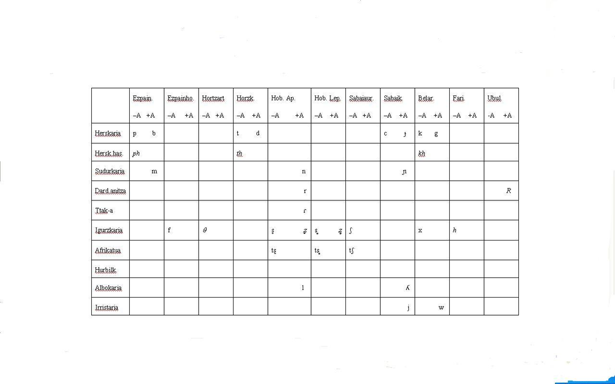

## Ezaugarri suprasegmentalak

- Azentua
- Intonazioa
- Abiada
- Etenak
- Bolumena

## Azentua

Silaba batek daraman prominentzia da.

## Intonazioa

Esaldi mailakoa da eta esaldi motak bereizteko erabiltzen da (galderak, harridurazkoak, enuntziatiboak…)

## Abiada

Hiztunak daukan abiadura testu egitean; hiztunaren ezaugarri pertsonalek eragina izan dezakete, baita tesua gauzatzen den egoeraren baldintzek ere.

Geldoa: mezuari eman nahi zaion garrantziarekin lotzen da

Testuen irakurketan, abiadura handiegiak, edo lar arin irakurtzeak, lapsus kopurua, artikulazio akatsak, etenen desegokitasuna eta ulermen-zailtasuna eragiten ditu.

## Etenak

Irakurketan eten grafikoekin bat etortzen dira sarritan.

Akatsik ohikoena bereizi ezin daitezkeen sintagmak apurtzea izaten da.

Bat-bateko testuetan eten gehiago egiten dira.

Etenak isilunedunak edota soinu luzaketak izan daitezke.

## Bolumena

# Orain, zuen taldeko bat analizatu behar duzue artikulazioaren eta aldagai suprasegmentalen arabera